# Mini Project 4

CUNY Retirement Plans

# Introduction

## Task 00: Install Packages and Libraries

```r
if (!require("data.table")) install.packages("data.table")
if (!require("dotenv")) install.packages("dotenv")
if (!require("dplyr")) install.packages("dplyr")
if (!require("DT")) install.packages("DT")
if (!require("glue")) install.packages("glue")
if (!require("httr2")) install.packages("httr2")
if (!require("plotly")) install.packages("plotly")
if (!require("scales")) install.packages("scales")
if (!require("tidyr")) install.packages("tidyr")
if (!require("tidyverse")) install.packages("tidyverse")
if (!require("tools")) install.packages("tools")

library(data.table)
library(dotenv)
library(dplyr)
library(DT)
library(glue)
library(httr2)
library(plotly)
library(scales)
library(tidyr)
library(tidyverse)
library(tools)
```

## Task 01: Register for AlphaVantage API Key

```r
# Key has been registeted previously
alpha_api_key <- Sys.getenv("ALPHA_API_KEY")
```

## Task 02: Register for FRED API Key

```r
# Key has been registeted previously
fred_api_key <- Sys.getenv("FRED_API_KEY")
```

## Task 03: Data Acquisition

Pulling in data on:

- Inflation
  - FRED
- Wage Growth
  - FRED
- US Equity Market total returns
  - AlphaVantage
- International Equity Market total returns
  - AlphaVantage
- Bond market total returns
  - FRED
- Short-term debt returns
  - FRED

```r
# Creating a request and clean function for FRED Data
series_url = "https://api.stlouisfed.org/fred/series/observations?series_id="

get_fred_data <- function(url,series_id,api_key){

  lookup_url <- paste0(url,series_id,"&api_key=",api_key,"&file_type=json")

  req <- request(lookup_url)

  resp <- req_perform(req)

  data <- resp_body_json(resp)

  df <- data$observations

  return(df)
}
```

```r
# Creating a similar function for Alpha Data

base_alpha_url <- "https://www.alphavantage.co/query"

get_alpha_data <- function(url,lookup_symbol,api_key){
  req <- request(url) |>
    req_url_query(
      `function` = "TIME_SERIES_DAILY",
      symbol=lookup_symbol,
      interval = "60min",
      apikey = alpha_api_key,
      outputsize = "full"
    )

  resp <- req_perform(req)

  data <- resp_body_json(resp)

  time_series <- data$`Time Series (Daily)`

  # Convert to dataframe
  df <- do.call(rbind, lapply(time_series, function(row) {
    as.data.frame(t(row), stringsAsFactors = FALSE)
  }))

  df$Date <- rownames(time_series)

  df <- rownames_to_column(df, var = "Date")

  # Remove the row names
  rownames(df) <- NULL

  # Ensure the Date column is in Date format
  df$Date <- as.Date(df$Date)

  df <- df |>
    rename(`open` = `1. open`,
           `high` = `2. high`,
           `low` = `3. low`,
           `close` = `4. close`,
           `volume` = `5. volume`)

  df <- df |>
    mutate(
      open = as.numeric(open),
      high = as.numeric(high),
      low = as.numeric(low),
      close = as.numeric(close),
      volume = as.numeric(volume)
    )

  # Create YearMonth column and calculate medians
  medians <- df |>
    mutate(YearMonth = format(Date, "%Y-%m")) |>
    group_by(YearMonth) |>
    summarize(across(
      c(open, high, low, close, volume),
      median,
      na.rm = TRUE
    )) |>
    ungroup()

  return(medians)
  }
```

### 3a. Inflation Data

```r
# Pulling this data from the FRED website
# If you look up the series ID in FRED, you can directly access the data and download its .CSV file there

inflation_series_id = "FPCPITOTLZGUSA"

inflation_df <- get_fred_data(url=series_url,series_id=inflation_series_id,api_key=fred_api_key)

clean_inflation_df <- data.frame(
  DATE = sapply(inflation_df, function(x) x$date),
  inflation_rate = as.numeric(sapply(inflation_df, function(x) x$value))
)

clean_inflation_df <- clean_inflation_df |>
  mutate(year = substr(DATE,start=0,stop=4),
         inflation_rate = round(inflation_rate,3),
         yoy_diff = round(inflation_rate - lag(inflation_rate),2),
         yoy_diff = if_else(is.na(yoy_diff), 0, yoy_diff)
         ) |>
  select(`Year` = year,
         `Inflation Rate` = inflation_rate,
         `YoY Differential` = yoy_diff)

clean_inflation_df |>
  DT::datatable()
```

|  | Year | Inflation Rate | YoY Differential |
| --- | --- | --- | --- |
| 1 | 1960 | 1.458 | 0 |
| 2 | 1961 | 1.071 | -0.39 |
| 3 | 1962 | 1.199 | 0.13 |
| 4 | 1963 | 1.24 | 0.04 |
| 5 | 1964 | 1.279 | 0.04 |
| 6 | 1965 | 1.585 | 0.31 |
| 7 | 1966 | 3.015 | 1.43 |
| 8 | 1967 | 2.773 | -0.24 |
| 9 | 1968 | 4.272 | 1.5 |
| 10 | 1969 | 5.462 | 1.19 |

[output cut: 54 more lines]

```r
print(glue("The Inflation Dataset covers a year range of {min(clean_inflation_df$Year)} to {max(clean_inflation_df$Year)}"))
```

```
The Inflation Dataset covers a year range of 1960 to 2023
```

### 3b. Wage Data

```r
wage_series_id = "FRBATLWGTUMHWG83O"

wage_df <- get_fred_data(url=series_url,series_id=wage_series_id,api_key=fred_api_key)

clean_wage_df <- data.frame(
  DATE = sapply(wage_df, function(x) x$date),
  wage_growth = as.numeric(sapply(wage_df, function(x) x$value))
)


clean_wage_df <- clean_wage_df |>
  mutate(year = substr(DATE,start=0,stop=4)) |>
  group_by(year) |>
  summarize(
    mwg = round(median(wage_growth, na.rm = TRUE), 1),
    null_months = sum(is.na(wage_growth)) # Count of NULL months
  ) |>
  ungroup() |>
  mutate(yoy_diff = round(mwg - lag(mwg),2),
         yoy_diff = if_else(is.na(yoy_diff), 0, yoy_diff)) |>
  select(
    `Year`= year,
    `NULL Month Count` = null_months,
    `Median Wage Growth` = mwg,
    `YoY Differential` = yoy_diff
  )

clean_wage_df |>
  DT::datatable()
```

|  | Year | NULL Month Count | Median Wage Growth | YoY Differential |
| --- | --- | --- | --- | --- |
| 1 | 1983 | 0 | 5.6 | 0 |
| 2 | 1984 | 0 | 5.4 | -0.2 |
| 3 | 1985 | 6 | 5.3 | -0.1 |
| 4 | 1986 | 9 | 4.9 | -0.4 |
| 5 | 1987 | 0 | 4.9 | 0 |
| 6 | 1988 | 0 | 5.1 | 0.2 |
| 7 | 1989 | 0 | 5.7 | 0.6 |
| 8 | 1990 | 0 | 5.6 | -0.1 |
| 9 | 1991 | 0 | 5.1 | -0.5 |
| 10 | 1992 | 0 | 4.2 | -0.9 |

[output cut: 32 more lines]

```r
print(glue("The Wage Dataset covers a year range of {min(clean_wage_df$Year)} to {max(clean_wage_df$Year)}"))
```

```
The Wage Dataset covers a year range of 1983 to 2024
```

### 3c. U.S. Equity Market Total Returns (Lookup Symbol = SPY)

```r
us_monthly_medians <- get_alpha_data(url=base_alpha_url,lookup_symbol="SPY",api_key=alpha_api_key)

us_monthly_medians <- us_monthly_medians |>
  mutate(
    year = substr(YearMonth,start=0,stop=4)
  ) |>
  group_by(year) |>
  summarize(across(
    c(open, high, low, close, volume),
    median,
    na.rm = TRUE
  )) |>
  ungroup() |>
  mutate(
    open = round(open,2),
    high = round(high, 2),
    low = round(low, 2),
    close = round(close, 2),
    high_low_diff = round(high - low, 2),
    open_close_diff = round(open - close, 2),
    yoy_diff = round(volume - lag(volume),2),
    yoy_diff = if_else(is.na(yoy_diff), 0, yoy_diff)
  ) |>
  select(
    `Year` = year,
    `Open` = open,
    `Close` = close,
    `High` = high,
    `Low` = low,
    `Traded Volume` = volume,
    `YoY Volume Difference` = yoy_diff
  )

us_monthly_medians |>
  DT::datatable()
```

|  | Year | Open | Close | High | Low | Traded Volume | YoY Volume Difference |
| --- | --- | --- | --- | --- | --- | --- | --- |
| 1 | 1999 | 141.31 | 141.08 | 141.78 | 140.18 | 5585200 | 0 |
| 2 | 2000 | 143.41 | 144.87 | 146.23 | 141.18 | 7137625 | 1552425 |
| 3 | 2001 | 118.62 | 118.79 | 119.23 | 117.15 | 11141625 | 4004000 |
| 4 | 2002 | 96.75 | 97.18 | 98.35 | 96.32 | 30119600 | 18977975 |
| 5 | 2003 | 99.13 | 99.35 | 99.75 | 98.42 | 38871875 | 8752275 |
| 6 | 2004 | 113.03 | 113.03 | 113.52 | 112.38 | 43678000 | 4806125 |
| 7 | 2005 | 120.29 | 120.28 | 120.78 | 119.66 | 56505450 | 12827450 |
| 8 | 2006 | 129.42 | 129.73 | 130.08 | 129.16 | 64345550 | 7840100 |
| 9 | 2007 | 147.28 | 147.46 | 148.3 | 146.67 | 143751300 | 79405750 |
| 10 | 2008 | 130.36 | 130.3 | 131.51 | 129.04 | 264919400 | 121168100 |

[output cut: 16 more lines]

```r
print(glue("The US Equity Market Dataset covers a year range of {min(us_monthly_medians$Year)} to {max(us_monthly_medians$Year)}"))
```

```
The US Equity Market Dataset covers a year range of 1999 to 2024
```

### 3d. International Equity Market Total Returns (Lookup Symbol = VXUS)

```r
intl_monthly_medians <- get_alpha_data(url=base_alpha_url,lookup_symbol="VXUS",api_key=alpha_api_key)

intl_monthly_medians <- intl_monthly_medians |>
  mutate(
    year = substr(YearMonth,start=0,stop=4)
  ) |>
  group_by(year) |>
  summarize(across(
    c(open, high, low, close, volume),
    median,
    na.rm = TRUE
  )) |>
  ungroup() |>
  mutate(
    open = round(open,2),
    high = round(high, 2),
    low = round(low, 2),
    close = round(close, 2),
    high_low_diff = round(high - low, 2),
    open_close_diff = round(open - close, 2),
    yoy_diff = round(volume - lag(volume),2),
    yoy_diff = if_else(is.na(yoy_diff), 0, yoy_diff)
  ) |>
  select(
    `Year` = year,
    `Open` = open,
    `Close` = close,
    `High` = high,
    `Low` = low,
    `Traded Volume` = volume,
    `YoY Volume Difference` = yoy_diff
  )

intl_monthly_medians |>
  DT::datatable()
```

|  | Year | Open | Close | High | Low | Traded Volume | YoY Volume Difference |
| --- | --- | --- | --- | --- | --- | --- | --- |
| 1 | 2011 | 49.94 | 49.77 | 50.43 | 49.48 | 49400 | 0 |
| 2 | 2012 | 44.53 | 44.47 | 44.75 | 44.24 | 101850 | 52450 |
| 3 | 2013 | 48.27 | 48.22 | 48.39 | 48.09 | 181825 | 79975 |
| 4 | 2014 | 52.12 | 52.05 | 52.23 | 51.83 | 245350 | 63525 |
| 5 | 2015 | 49.52 | 49.65 | 49.73 | 49.34 | 501112.75 | 255762.75 |
| 6 | 2016 | 45.53 | 45.51 | 45.62 | 45.38 | 640907.25 | 139794.5 |
| 7 | 2017 | 52.72 | 52.81 | 52.86 | 52.59 | 646171.5 | 5264.25 |
| 8 | 2018 | 55.34 | 55.36 | 55.42 | 55.12 | 735763 | 89591.5 |
| 9 | 2019 | 52.03 | 51.97 | 52.19 | 51.88 | 1214692 | 478929 |
| 10 | 2020 | 53.28 | 53.14 | 53.42 | 52.85 | 2966772 | 1752080 |

[output cut: 4 more lines]

```r
print(glue("The International Equity Market Dataset covers a year range of {min(intl_monthly_medians$Year)} to {max(intl_monthly_medians$Year)}"))
```

```
The International Equity Market Dataset covers a year range of 2011 to 2024
```

### 3e. Bond Returns

```r
bond_series_id = "BAMLCC0A4BBBTRIV"

bond_df <- get_fred_data(url=series_url,series_id=bond_series_id,api_key=fred_api_key)

clean_bond_df <- data.frame(
  DATE = sapply(bond_df, function(x) x$date),
  bond = as.numeric(sapply(bond_df, function(x) x$value))
)

clean_bond_df <- clean_bond_df |>
  mutate(year = substr(DATE,start=0,stop=4)) |>
  group_by(year) |>
  summarize(
    median_bond_price = median(bond, na.rm = TRUE)
  ) |>
  ungroup() |>
  mutate(yoy_diff = round(median_bond_price - lag(median_bond_price),2),
         yoy_diff = if_else(is.na(yoy_diff), 0, yoy_diff)) |>
  select(
    `Year`= year,
    `Median Bond Price` = median_bond_price,
    `YoY Differential` = yoy_diff
  )

clean_bond_df |>
  DT::datatable()
```

|  | Year | Median Bond Price | YoY Differential |
| --- | --- | --- | --- |
| 1 | 1988 | 100.3 | 0 |
| 2 | 1989 | 109.815 | 9.52 |
| 3 | 1990 | 115.625 | 5.81 |
| 4 | 1991 | 128.91 | 13.28 |
| 5 | 1992 | 149.9 | 20.99 |
| 6 | 1993 | 171.04 | 21.14 |
| 7 | 1994 | 172.6 | 1.56 |
| 8 | 1995 | 195.84 | 23.24 |
| 9 | 1996 | 209.38 | 13.54 |
| 10 | 1997 | 229.92 | 20.54 |

[output cut: 27 more lines]

```r
print(glue("The Bond Dataset covers a year range of {min(clean_bond_df$Year)} to {max(clean_bond_df$Year)}"))
```

```
The Bond Dataset covers a year range of 1988 to 2024
```

### 3f. Short-Term Debt Returns

```r
short_term_debt_series_id = "QFRD304INFUSNO"

short_term_debt_df <- get_fred_data(url=series_url,series_id=short_term_debt_series_id,api_key=fred_api_key)

clean_short_term_debt_df <- data.frame(
  DATE = sapply(short_term_debt_df, function(x) x$date),
  quarterly_financials = as.numeric(sapply(short_term_debt_df, function(x) x$value))
)

clean_short_term_debt_df <- clean_short_term_debt_df |>
  mutate(year = substr(DATE,start=0,stop=4)) |>
  group_by(year) |>
  summarize(
    annual_financials = round(median(quarterly_financials, na.rm = TRUE), 1)
  ) |>
  mutate(yoy_diff = round(annual_financials - lag(annual_financials),2),
         yoy_diff = if_else(is.na(yoy_diff), 0, yoy_diff)) |>
  ungroup() |>
  select(
    `Year` = year,
    `Annual Financials` = annual_financials,
    `YoY Differential` = yoy_diff
  )

clean_short_term_debt_df |>
  DT::datatable()
```

|  | Year | Annual Financials | YoY Differential |
| --- | --- | --- | --- |
| 1 | 2009 | 9616 | 0 |
| 2 | 2010 | 4510.5 | -5105.5 |
| 3 | 2011 | 3047.5 | -1463 |
| 4 | 2012 | 2077.5 | -970 |
| 5 | 2013 | 3097 | 1019.5 |
| 6 | 2014 | 8072 | 4975 |
| 7 | 2015 | 10730.5 | 2658.5 |
| 8 | 2016 | 20956 | 10225.5 |
| 9 | 2017 | 16408.5 | -4547.5 |
| 10 | 2018 | 9187.5 | -7221 |

[output cut: 6 more lines]

```r
print(glue("The Short-Term Debt Dataset covers a year range of {min(clean_short_term_debt_df$Year)} to {max(clean_short_term_debt_df$Year)}"))
```

```
The Short-Term Debt Dataset covers a year range of 2009 to 2024
```

## Task 04: Initial Analysis

There are now 6 datasets to look into.

The first step is to do some EDA. We could look at the data as a whole or compare like-to-like.

This divides our data into three groups: Inflation + Wages, US + International Markets, and Bond + Short-Term Debt.

There are two reasons for this: the first is these compare similar indicators to each other. The second is the date ranges are different across the board, so throwing everything into a single table and graph would just look messy.

```r
# dropping NULL month count from wages since it won't really apply to any further analysis
wgs <- clean_wage_df |>
  select(
    -`NULL Month Count`
  )

# join dfs on year, this will shorten the overall date range to 1983-2023 (40 year span)
infl_wgs_df <- clean_inflation_df |>
  inner_join(wgs, by = "Year") |>
  select(
    `Year`,
    `Inflation Rate`,
    `YoY Inflation Differential` = `YoY Differential.x`,
    `Median Wage Growth`,
    `YoY Wages Differential` = `YoY Differential.y`
  ) |>
  mutate(
    `YoY Inflation Differential` = if_else(
      Year == 1983, 0, `YoY Inflation Differential` # Since it's cutting off a portion of the inflation dataset...
    )
  )

# quick look at the table
infl_wgs_df |>
  DT::datatable()
```

|  | Year | Inflation Rate | YoY Inflation Differential | Median Wage Growth | YoY Wages Differential |
| --- | --- | --- | --- | --- | --- |
| 1 | 1983 | 3.212 | 0 | 5.6 | 0 |
| 2 | 1984 | 4.301 | 1.09 | 5.4 | -0.2 |
| 3 | 1985 | 3.546 | -0.76 | 5.3 | -0.1 |
| 4 | 1986 | 1.898 | -1.65 | 4.9 | -0.4 |
| 5 | 1987 | 3.665 | 1.77 | 4.9 | 0 |
| 6 | 1988 | 4.078 | 0.41 | 5.1 | 0.2 |
| 7 | 1989 | 4.827 | 0.75 | 5.7 | 0.6 |
| 8 | 1990 | 5.398 | 0.57 | 5.6 | -0.1 |
| 9 | 1991 | 4.235 | -1.16 | 5.1 | -0.5 |
| 10 | 1992 | 3.029 | -1.21 | 4.2 | -0.9 |

[output cut: 31 more lines]

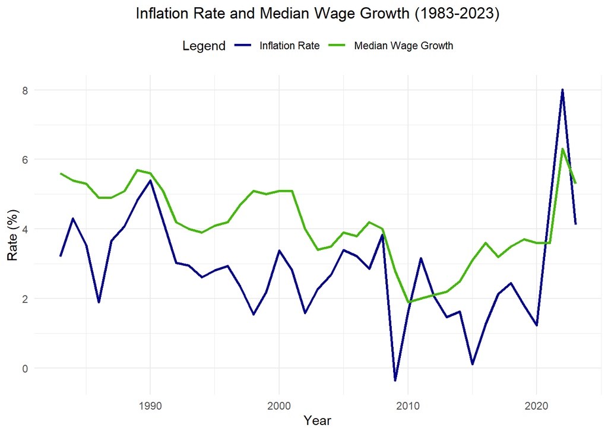

```r
# Ensure Year is numeric
infl_wgs_df$Year <- as.numeric(as.character(infl_wgs_df$Year))

# Inflation Rate and Median Wage Growth Plot
inflation_wage_plot <- ggplot(infl_wgs_df, aes(x = Year)) +
  geom_line(aes(y = `Inflation Rate`, color = "Inflation Rate"), size = 1) +
  geom_line(aes(y = `Median Wage Growth`, color = "Median Wage Growth"), size = 1) +
  scale_color_manual(values = c("Inflation Rate" = "darkblue", "Median Wage Growth" = "#44b80a")) +
  labs(
    title = "Inflation Rate and Median Wage Growth (1983-2023)",
    x = "Year",
    y = "Rate (%)",
    color = "Legend"
  ) +
  theme_minimal() +
  theme(
    plot.title = element_text(hjust = 0.5),
    legend.position = "top"
  ) +
  scale_x_continuous(breaks = seq(1960, 2024, by = 10)) +
  scale_y_continuous()

print(inflation_wage_plot)
```

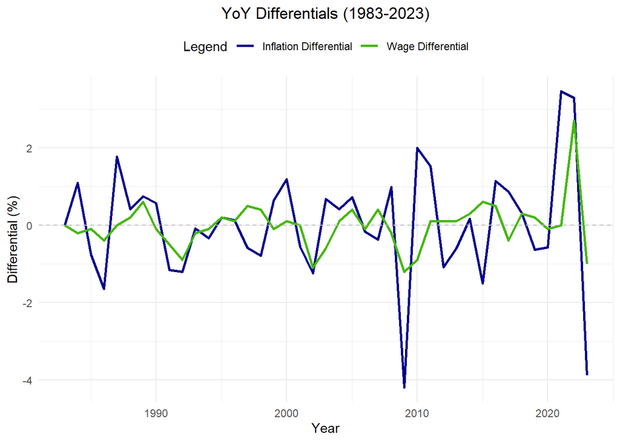

```r
infl_wgs_yoy_plot <- ggplot(infl_wgs_df, aes(x = Year)) +
  geom_line(aes(y = `YoY Inflation Differential`, color = "Inflation Differential"), size = 1) +
  geom_line(aes(y = `YoY Wages Differential`, color = "Wage Differential"), size = 1) +
  scale_color_manual(values = c("Inflation Differential" = "darkblue", "Wage Differential" = "#44b80a")) +
  labs(
    title = "YoY Differentials (1983-2023)",
    x = "Year",
    y = "Differential (%)",
    color = "Legend"
  ) +
  theme_minimal() +
  theme(
    plot.title = element_text(hjust = 0.5),
    legend.position = "top"
  ) +
  scale_x_continuous(breaks = seq(1960, 2024, by = 10)) +
  scale_y_continuous() +
  geom_hline(yintercept = 0, linetype = "dashed", color = "gray") # Centered at 0

print(infl_wgs_yoy_plot)
```

Market Dataframe and Plots

```r
market_df <- us_monthly_medians |>
  inner_join(intl_monthly_medians, by = "Year", suffix = c("_US", "_Intl")) |>
  mutate(
    Avg_Price_US = (High_US + Low_US) / 2,
    Avg_Price_Intl = (High_Intl + Low_Intl) / 2
  ) |>
  select(
    `Year`,
    `Average Price U.S. Markets` = `Avg_Price_US`, # decided to go with the average
    `Traded Volume US` = `Traded Volume_US`,
    `Average Price International Markets` = `Avg_Price_Intl`,
    `Traded Volume Intl` = `Traded Volume_Intl`
  )

market_df |>
  DT::datatable()
```

|  | Year | Average Price U.S. Markets | Traded Volume US | Average Price International Markets | Traded Volume Intl |
| --- | --- | --- | --- | --- | --- |
| 1 | 2011 | 128.57 | 197152577.25 | 49.955 | 49400 |
| 2 | 2012 | 139.065 | 136465466.5 | 44.495 | 101850 |
| 3 | 2013 | 165.69 | 113124440.5 | 48.24 | 181825 |
| 4 | 2014 | 194.71 | 101842250.5 | 52.03 | 245350 |
| 5 | 2015 | 208.695 | 109178809.25 | 49.535 | 501112.75 |
| 6 | 2016 | 211.4 | 89071700 | 45.5 | 640907.25 |
| 7 | 2017 | 244.26 | 64222601.5 | 52.725 | 646171.5 |
| 8 | 2018 | 273.87 | 87947626 | 55.27 | 735763 |
| 9 | 2019 | 290.34 | 65072764.25 | 52.035 | 1214692 |
| 10 | 2020 | 329.805 | 68855727.75 | 53.13500000000001 | 2966772 |

[output cut: 4 more lines]

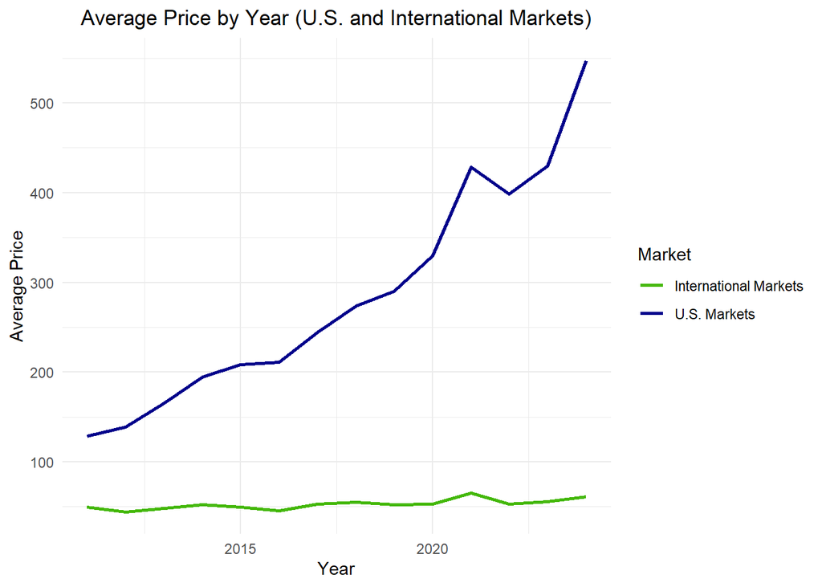

```r
market_df$Year <- as.numeric(as.character(market_df$Year))

ggplot(market_df, aes(x = Year)) +
  geom_line(aes(y = `Average Price U.S. Markets`, color = "U.S. Markets"), size = 1) +
  geom_line(aes(y = `Average Price International Markets`, color = "International Markets"), size = 1) +
  scale_color_manual(values = c("U.S. Markets" = "darkblue", "International Markets" = "#44b80a")) +
  labs(
    title = "Average Price by Year (U.S. and International Markets)",
    x = "Year",
    y = "Average Price",
    color = "Market"
  ) +
  theme_minimal() +
  theme(plot.title = element_text(hjust = 0.5))
```

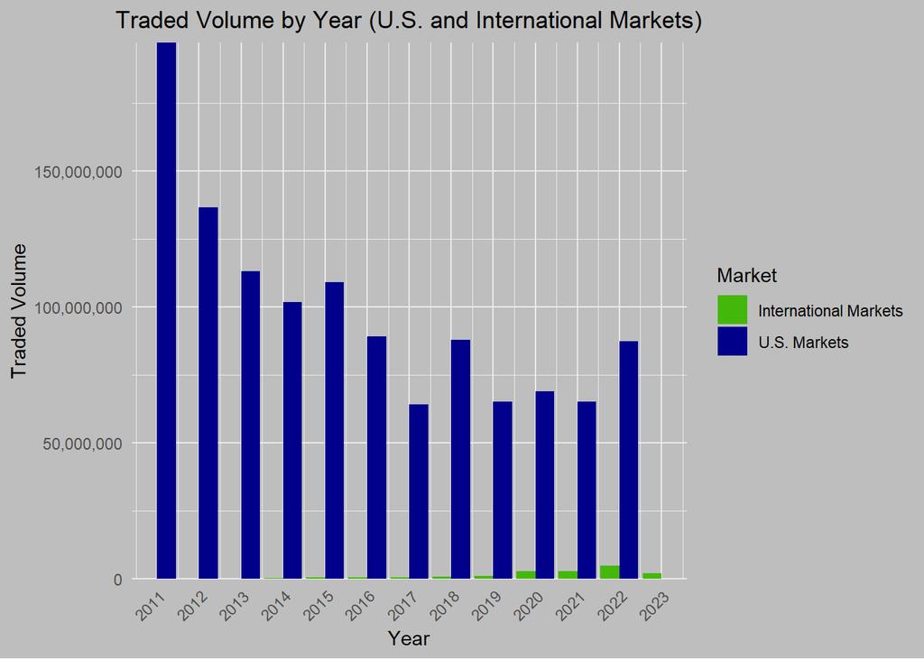

```r
# Transform data to long format for plotting for bar graph
volume_data <- market_df |>
  pivot_longer(
    cols = c(`Traded Volume US`, `Traded Volume Intl`),
    names_to = "Market",
    values_to = "Traded Volume"
  ) |>
  mutate(Market = recode(Market,
                         `Traded Volume US` = "U.S. Markets",
                         `Traded Volume Intl` = "International Markets"))

# Overlaid bar graph
ggplot(volume_data, aes(x = Year, y = `Traded Volume`, fill = Market)) +
  geom_bar(stat = "identity", position = "dodge") +
  scale_fill_manual(values = c("U.S. Markets" = "darkblue", "International Markets" = "#44b80a")) +
  scale_y_continuous(
    labels = scales::comma, # Format Y-axis with commas
    expand = c(0, 0)        # Remove extra space at the bottom of the bars
  ) +
  scale_x_continuous(
    breaks = seq(2011, 2023, by = 1),
    limits = c(2011, 2023)
  ) +
  labs(
    title = "Traded Volume by Year (U.S. and International Markets)",
    x = "Year",
    y = "Traded Volume",
    fill = "Market"
  ) +
  theme_minimal() +
  theme(
    plot.title = element_text(hjust = 0.5),
    axis.text.x = element_text(angle = 45, hjust = 1),
    plot.background = element_rect(fill = "gray", color = NA),
    panel.background = element_rect(fill = "gray", color = NA)
  )
```

Finally, looking at a bonds-to-debt ratio over time to try and get an understanding for how investing and risk in the U.S. has looked over time.

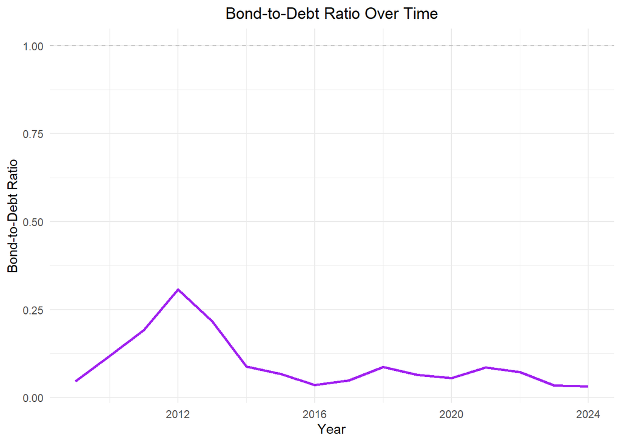

```r
# Combine the two datasets on Year
bonds_and_debts <- clean_bond_df |>
  inner_join(clean_short_term_debt_df, by = "Year", suffix = c("_Bond", "_Debt")) |>
  mutate(
    Bond_to_Debt_Ratio = `Median Bond Price` / `Annual Financials` # Calculate bond-to-debt ratio
  )

bonds_and_debts$Year <- as.numeric(as.character(bonds_and_debts$Year))

ggplot(bonds_and_debts, aes(x = Year, y = Bond_to_Debt_Ratio)) +
  geom_line(color = "purple", size = 1) +
  geom_hline(yintercept = 1, linetype = "dashed", color = "gray") +
  labs(
    title = "Bond-to-Debt Ratio Over Time",
    x = "Year",
    y = "Bond-to-Debt Ratio"
  ) +
  theme_minimal() +
  theme(plot.title = element_text(hjust = 0.5))
```

## Task 05: Historical Comparison

Now we’ll compare the two plans, TRS and ORP, to get a sense of how each performs, for a CUNY employee who joined in the first month of the historical data.

For this, we’ll look at Professor Bob. Bob Started teaching at Baruch back in 1983; he’s seen his income increase over time exactly in-line with his fellow Americans, and he’s been saving from the minute he took the position. Bob retired in 2013, 30 years after starting. He’s now had 10 years of post-retirement pension. Although he is still living pretty reasonably well-off, he wonders if he made the right choice.

You see, back in 1983, he was offered two plans. The more traditional plan, the *Teachers Retirement System* (TRS), where Baruch takes the brunt of the market risk for Bob, and the new *Optional Retirement Plan* (ORP), a more aggressive approach to financial planning, which would allow Bob to more directly invest in the market, similar to a 401(k).

Bob is a more prudent person, always has been, he took the more understandable (and still very good) TRS, but he’s always wondered “what if?”.

Let’s help Bob out. Looking at market data over the same time span and understanding how each plan works, would Bob have been better off with the ORP, or did he make the right decision sticking with the TRS?

```r
# The story of Professor Bob
working_bob <- wgs |>
  filter(Year <= 2013) |>
  rename(mwg = `Median Wage Growth`) |>
  mutate(Income = ifelse(Year == 1983, 52267.01, NA),
         mwg = (mwg / 100)) |>
  select(-`YoY Differential`)



for (i in 2:nrow(working_bob)) {
  working_bob$Income[i] <- working_bob$Income[i - 1] * (1 + working_bob$mwg[i])
}

working_bob$Year <- as.numeric(as.character(working_bob$Year))

print(glue("Professor Bob's starting income in {min(working_bob$Year)} is {dollar(round(min(working_bob$Income), 2))}.\n His salary at retirement in {max(working_bob$Year)} is {dollar(round(max(working_bob$Income), 2))}."))
```

```
Professor Bob's starting income in 1983 is $52,267.01.
His salary at retirement in 2013 is $177,919.
```

```r
# Create the ggplot2 object with custom tooltip
working_bob_plot <- ggplot(working_bob, aes(x = Year, y = Income)) +
  geom_line(color = "#44b80a", size = 1.5) +  # Line for Income
  geom_hline(yintercept = 100000, linetype = "dashed", color = "gray") +
  geom_hline(yintercept = 200000, linetype = "dashed", color = "gray") +
  labs(
    title = "Professor Bob's Income Over Time (1983 - 2013)",
    x = "Year",
    y = "Income ($)"
  ) +
  scale_x_continuous(
    breaks = seq(min(working_bob$Year), max(working_bob$Year), by = 5)
  ) +
  scale_y_continuous(labels = dollar_format(accuracy = 0.01)) + # $ format
  theme_minimal() +
  theme(
    plot.title = element_text(hjust = 0.5),
    axis.text.x = element_text(angle = 45, hjust = 1),
    plot.background = element_rect(fill = "gray", color = NA),
    panel.background = element_rect(fill = "gray", color = NA)
  )

working_bob_plot <- working_bob_plot +
  geom_line(aes(text = paste0("Year: ", Year, "<br>Income: ", dollar(Income, accuracy = 0.01))), size = 1, color = NA)

# make it interactive
bobs_working_plot <- ggplotly(working_bob_plot, tooltip = "text")

print(bobs_working_plot)
```

[output not shown]

The exact math behind each retirement package can get a little tricky. For TRS, first, employees pay a fixed percentage of their paycheck into the pension fund based on their AGI.

We can monitor Bob’s contributions over the years here:

```r
# TRS employee contribution function
trs_pct <- function(salary){
  case_when(
    salary <= 45000 ~ 0.03,
    salary <= 55000 ~ 0.035,
    salary <= 75000 ~ 0.045,
    salary <= 100000 ~ 0.0575,
    TRUE ~ 0.06
  )
}


# Bob's contributions
working_bob <- working_bob |>
  mutate(
    bobs_contributions = round(Income * trs_pct(Income),2)
  )


# View Bob's contributions in-line w/ MWG in the U.S.
working_bob |>
  mutate(Income = round(Income,2)) |>
  rename(`Median Wage Growth (U.S.)`= mwg,
         `Bob's Income` = Income) |>
  DT::datatable(
    options = list(pageLength = 11,
                   columnDefs = list(
                     # Adding commas for these columns
                     list(
                       targets = c(3,4),
                       render = JS(
                         "function(data, type, row, meta) {",
                         "  return type === 'display' ? '$ ' + data.toString().replace(/\\B(?=(\\d{3})+(?!\\d))/g, ',') : data;",
                         "}"
                       )
                     ),
                     # Formatting as percentages
                     list(
                       targets = c(2),
                       render = JS(
                         "function(data, type, row, meta) {",
                         "  return type === 'display' ? (data*100).toFixed(2) + '%' : data;",  # Formatting as percentage
                         "}"
                       )
                     )
                   )
    )
  )
```

|  | Year | Median Wage Growth (U.S.) | Bob's Income | bobs_contributions |
| --- | --- | --- | --- | --- |
| 1 | 1983 | 0.05599999999999999 | 52267.01 | 1829.35 |
| 2 | 1984 | 0.05400000000000001 | 55089.43 | 2479.02 |
| 3 | 1985 | 0.053 | 58009.17 | 2610.41 |
| 4 | 1986 | 0.049 | 60851.62 | 2738.32 |
| 5 | 1987 | 0.049 | 63833.35 | 2872.5 |
| 6 | 1988 | 0.051 | 67088.85 | 3019 |
| 7 | 1989 | 0.057 | 70912.91 | 3191.08 |
| 8 | 1990 | 0.05599999999999999 | 74884.03 | 3369.78 |
| 9 | 1991 | 0.051 | 78703.12 | 4525.43 |
| 10 | 1992 | 0.042 | 82008.65 | 4715.5 |

[output cut: 21 more lines]

Then, the retirement benefit is calculated based on a *Final Average Salary*, which computes the average of the final 3 years salary for an employee to use in a calculation, which also factors in the number of years an employee worked for Baruch.

For Bob, that is:

[output not shown]

What this means is, the benefit amount is increased annually in-line with the rate of inflation; the exact calculation halves the rate of inflation then rounds-up to the nearest tenth, for example a 2.9% rate of inflation divided by 2 and rounded up to the nearest-tenth returns a 1.5% annual increase. However, the increase exists within a band of 1-3% and can not exceed that band on either end.

## Task 06: Fixed-Rate Analysis

## Task 07: Monte-Carlo Analysis